# COVID-19 Report Interactive

### Updated as of Friday, March 12, 2021 at 9:35 AM (EST)

Good Day:

Shown below is a current **draft** in continual development and error checking. Please feel free to reach out with suggestions or issues! If you are curious about the situation in specific places in the USA (state/county level) or international locations, please click [**here**](http://ec2-3-17-139-199.us-east-2.compute.amazonaws.com:3838/shiny_covid19_aws/).

### USA Overall

> As of yesterday, there has been a total of 29,309,724 cases of COVID-19 in the USA. This is a change of 62,689 (0.21%) new cases since the day prior. The 7 day moving average is currently 6.294e+04 new cases which is a -0.13% change since the day prior and -2.05% change since the week prior. The immediate trend is heading downward. Based on the addition of yesterday’s data, yesterday was not an inflection point (days since last inflection point: 2 –> 2021-03-10).

#### **7-day moving average of new cases in the US (2020-01-21 to 2021-03-11)**

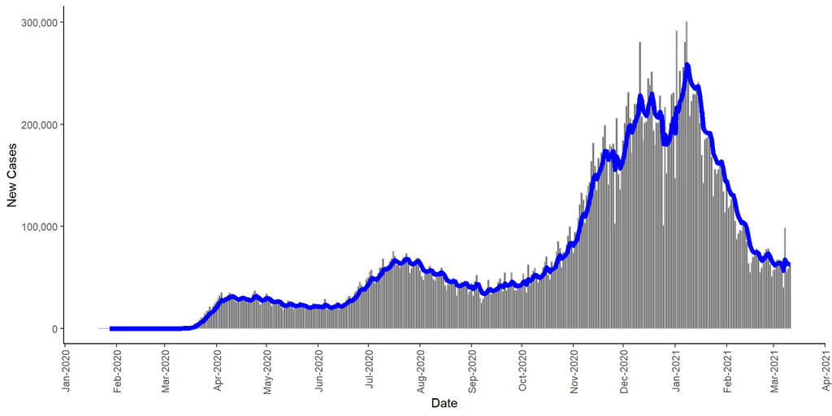

### State Consecutive Day Trends

> Of the 51 US states monitored, **1 (1.96%)** show consecutive increase in their 7-day moving average of new COVID-19 cases for at least 7 days. **25 (49.02%)** show consecutive decrease for at least 7 days.

#### **1** State(s) with Consecutive Increase

| State | Cases per 100,000 | Consecutive Days |
| --- | --- | --- |
| Michigan | 20 | 17 |

#### **25** State(s) with Consecutive Decrease

| State | Cases per 100,000 | Consecutive Days |
| --- | --- | --- |
| Rhode Island | 37 | 7 |
| New York | 35 | 8 |
| Florida | 22 | 14 |
| South Carolina | 21 | 50 |
| Connecticut | 21 | 10 |
| Kentucky | 20 | 14 |
| Pennsylvania | 20 | 7 |
| Texas | 19 | 10 |
| Utah | 18 | 57 |
| Georgia | 18 | 10 |
| North Carolina | 18 | 33 |
| Oklahoma | 15 | 56 |
| Virginia | 15 | 28 |
| Mississippi | 15 | 9 |
| Ohio | 14 | 57 |
| Montana | 14 | 16 |
| Illinois | 13 | 13 |
| Wyoming | 12 | 8 |
| Louisiana | 11 | 10 |
| New Mexico | 11 | 13 |
| California | 10 | 56 |
| Wisconsin | 10 | 58 |
| Kansas | 10 | 18 |
| Washington | 9 | 17 |
| Oregon | 7 | 11 |

### States Detailed

| State | Cases per 100,000 | Trend | ICU Stress | Inpatient Stress |
| --- | --- | --- | --- | --- |
| Missouri | 96 |  | extreme | moderate |
| New Jersey | 40 |  | high | moderate |
| Rhode Island | 37 |  | extreme | moderate |
| Delaware | 36 |  | extreme | low |
| New York | 35 |  | extreme | high |
| Massachusetts | 22 |  | extreme | low |
| District of Columbia | 22 |  | extreme | moderate |
| Alaska | 22 |  | extreme | low |
| Florida | 22 |  | extreme | moderate |
| South Carolina | 21 |  | extreme | moderate |
| Connecticut | 21 |  | high | moderate |
| Michigan | 20 |  | extreme | low |
| Kentucky | 20 |  | extreme | low |
| Pennsylvania | 20 |  | extreme | moderate |
| Idaho | 19 |  | extreme | low |
| Texas | 19 |  | extreme | moderate |
| South Dakota | 19 |  | high | low |
| Minnesota | 18 |  | extreme | low |
| Utah | 18 |  | extreme | low |
| Georgia | 18 |  | extreme | moderate |
| North Carolina | 18 |  | extreme | moderate |
| Colorado | 18 |  | extreme | low |
| Tennessee | 18 |  | extreme | low |
| Vermont | 18 |  | extreme | low |
| Arizona | 17 |  | high | moderate |
| New Hampshire | 17 |  | extreme | low |
| Iowa | 16 |  | extreme | low |
| West Virginia | 15 |  | extreme | low |
| Oklahoma | 15 |  | extreme | low |
| Virginia | 15 |  | extreme | moderate |
| Mississippi | 15 |  | extreme | low |
| Alabama | 15 |  | extreme | low |
| Nebraska | 14 |  | extreme | low |
| Ohio | 14 |  | extreme | low |
| Montana | 14 |  | high | low |
| Maryland | 13 |  | extreme | high |
| Nevada | 13 |  | extreme | moderate |
| Maine | 13 |  | extreme | low |
| Illinois | 13 |  | high | low |
| Indiana | 12 |  | high | low |
| Arkansas | 12 |  | extreme | low |
| Wyoming | 12 |  | high | low |
| Louisiana | 11 |  | extreme | low |
| New Mexico | 11 |  | extreme | low |
| North Dakota | 11 |  | high | low |
| California | 10 |  | extreme | moderate |
| Wisconsin | 10 |  | high | low |
| Kansas | 10 |  | extreme | low |
| Washington | 9 |  | extreme | low |
| Oregon | 7 |  | extreme | low |
| Hawaii | 4 |  | extreme | low |

### Hospital Status (Beta)

> The following illustrates the current situation in intensive care units (ICUs) in the USA. On average, the stress on ICUs across the country is *extreme*. Stress definitions can be found in the References tab.

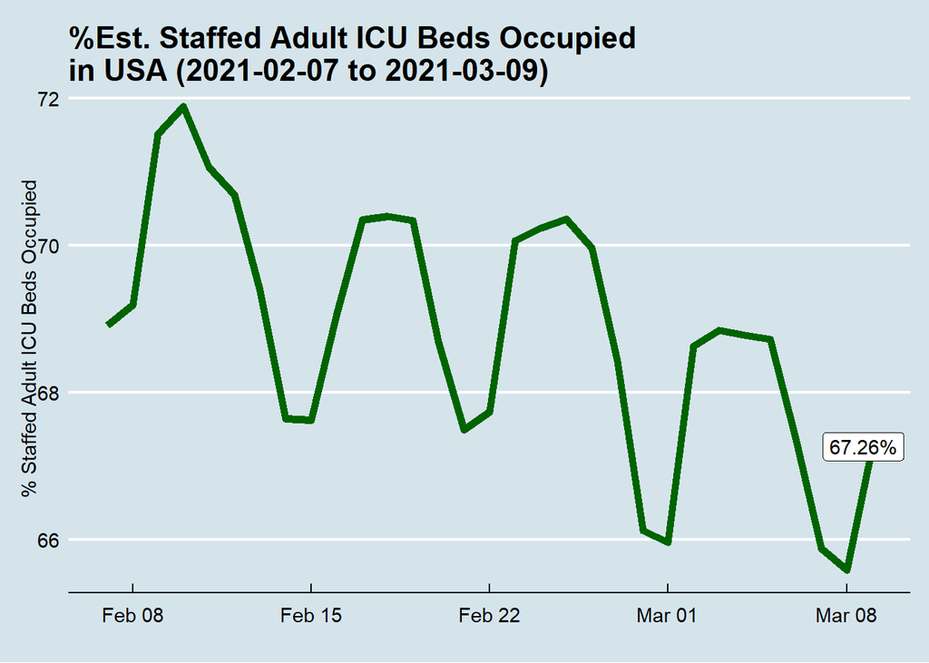

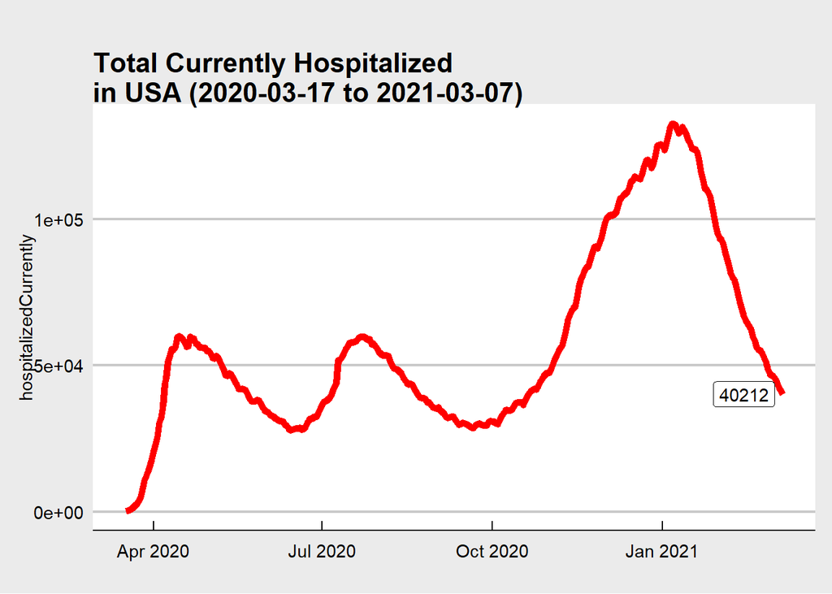

### Region by Region

#### west

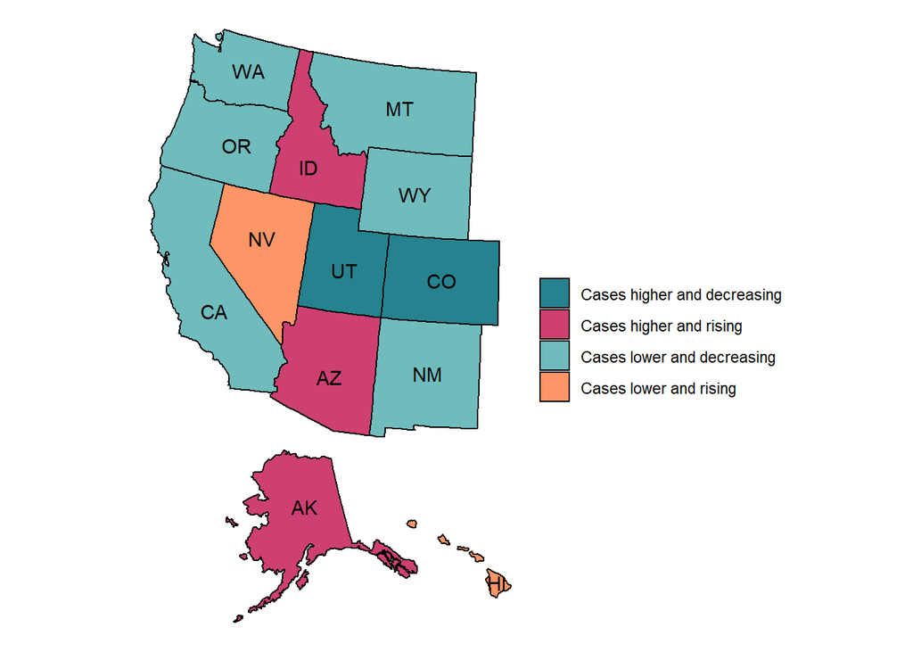

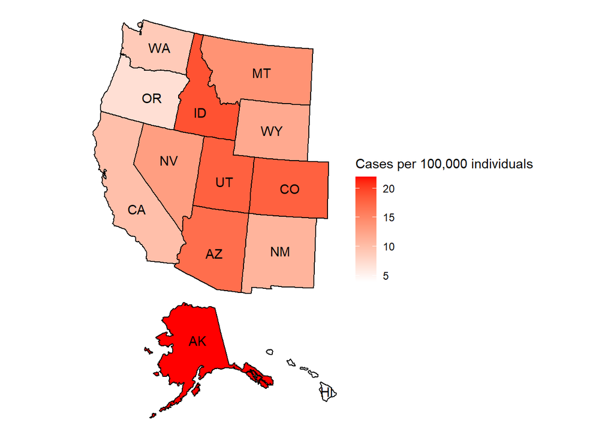

| State | Cases per 100,000 | Trend | ICU Stress | Inpatient Stress |
| --- | --- | --- | --- | --- |
| Alaska | 22 |  | extreme | low |
| Idaho | 19 |  | extreme | low |
| Utah | 18 |  | extreme | low |
| Colorado | 18 |  | extreme | low |
| Arizona | 17 |  | high | moderate |
| Montana | 14 |  | high | low |
| Nevada | 13 |  | extreme | moderate |
| Wyoming | 12 |  | high | low |
| New Mexico | 11 |  | extreme | low |
| California | 10 |  | extreme | moderate |
| Washington | 9 |  | extreme | low |
| Oregon | 7 |  | extreme | low |
| Hawaii | 4 |  | extreme | low |

#### south

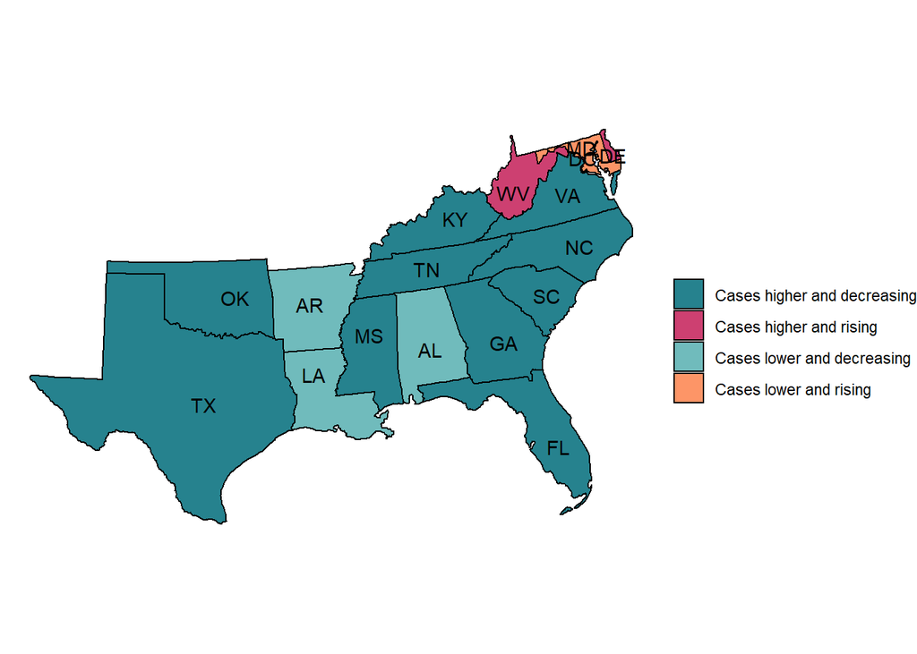

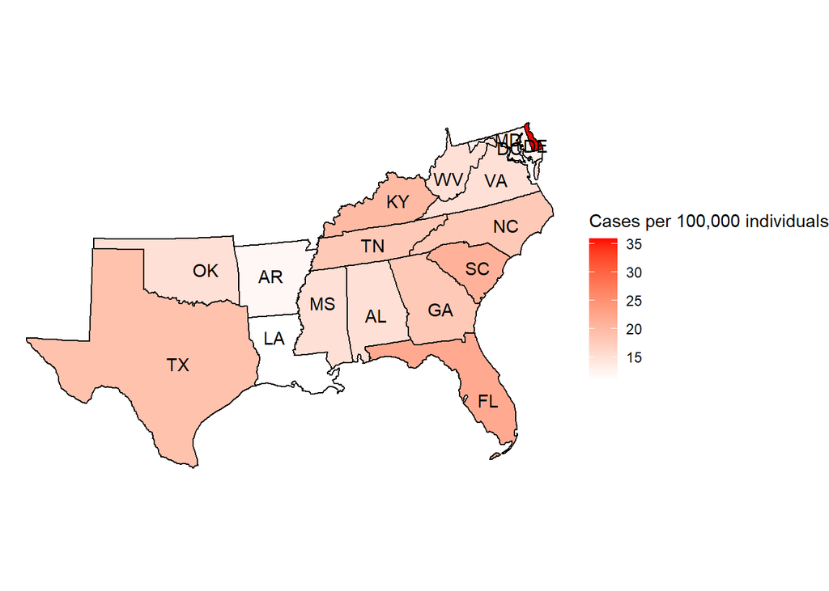

| State | Cases per 100,000 | Trend | ICU Stress | Inpatient Stress |
| --- | --- | --- | --- | --- |
| Delaware | 36 |  | extreme | low |
| District of Columbia | 22 |  | extreme | moderate |
| Florida | 22 |  | extreme | moderate |
| South Carolina | 21 |  | extreme | moderate |
| Kentucky | 20 |  | extreme | low |
| Texas | 19 |  | extreme | moderate |
| Georgia | 18 |  | extreme | moderate |
| North Carolina | 18 |  | extreme | moderate |
| Tennessee | 18 |  | extreme | low |
| West Virginia | 15 |  | extreme | low |
| Oklahoma | 15 |  | extreme | low |
| Virginia | 15 |  | extreme | moderate |
| Mississippi | 15 |  | extreme | low |
| Alabama | 15 |  | extreme | low |
| Maryland | 13 |  | extreme | high |
| Arkansas | 12 |  | extreme | low |
| Louisiana | 11 |  | extreme | low |

#### midwest

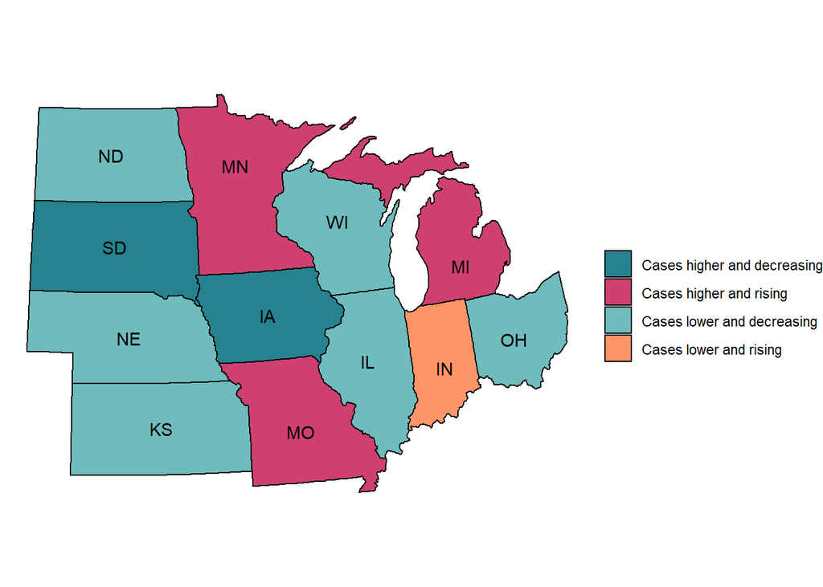

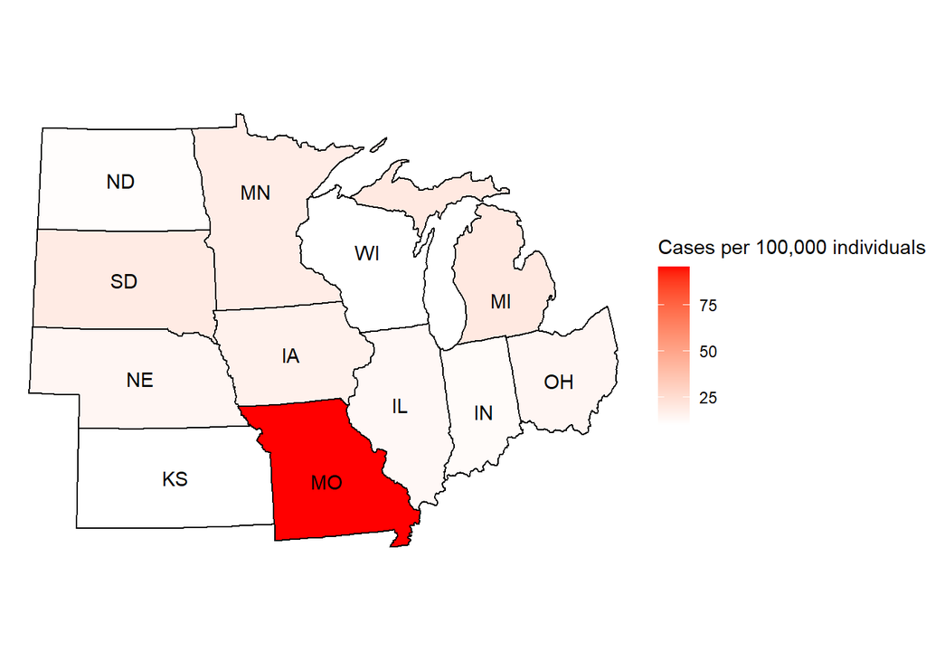

| State | Cases per 100,000 | Trend | ICU Stress | Inpatient Stress |
| --- | --- | --- | --- | --- |
| Missouri | 96 |  | extreme | moderate |
| Michigan | 20 |  | extreme | low |
| South Dakota | 19 |  | high | low |
| Minnesota | 18 |  | extreme | low |
| Iowa | 16 |  | extreme | low |
| Nebraska | 14 |  | extreme | low |
| Ohio | 14 |  | extreme | low |
| Illinois | 13 |  | high | low |
| Indiana | 12 |  | high | low |
| North Dakota | 11 |  | high | low |
| Wisconsin | 10 |  | high | low |
| Kansas | 10 |  | extreme | low |

#### northeast

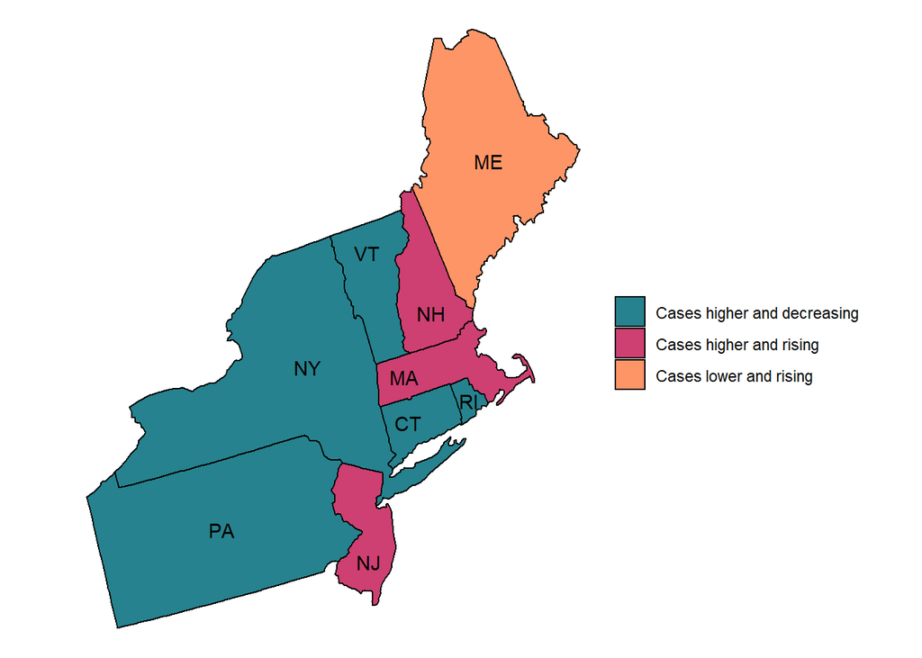

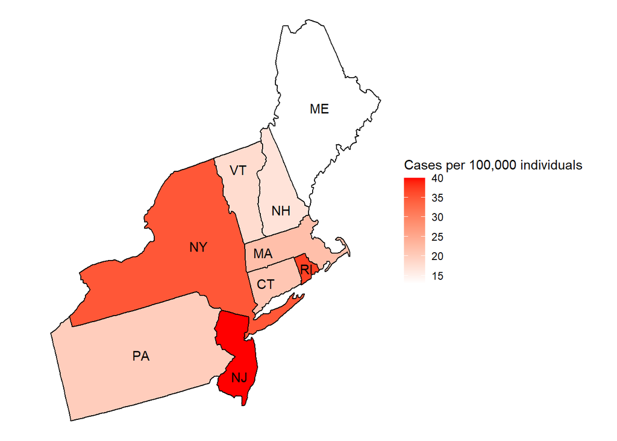

| State | Cases per 100,000 | Trend | ICU Stress | Inpatient Stress |
| --- | --- | --- | --- | --- |
| New Jersey | 40 |  | high | moderate |
| Rhode Island | 37 |  | extreme | moderate |
| New York | 35 |  | extreme | high |
| Massachusetts | 22 |  | extreme | low |
| Connecticut | 21 |  | high | moderate |
| Pennsylvania | 20 |  | extreme | moderate |
| Vermont | 18 |  | extreme | low |
| New Hampshire | 17 |  | extreme | low |
| Maine | 13 |  | extreme | low |

### References

**ICU stress definitions:**

- **low**: less than 10% of ICU Usage
- **moderate**: 10-29% of ICU Usage
- **high**: 30-59% of ICU Usage
- **extreme**: greater than 60% of ICU Usage

**Inpatient stress definitions:**

- **low**: less than 5% of hospital beds occupied by COVID-19 patients
- **moderate**: 5-9% of hospital beds occupied by COVID-19 patients
- **high**: 10-19% of hospital beds occupied by COVID-19 patients
- **extreme**: greater than 20% of hospital beds occupied by COVID-19 patients

Data from:

- [NYTimes COVID-19 Github](https://github.com/nytimes/covid-19-data)
- [JHU COVID-19 Github](https://github.com/CSSEGISandData/COVID-19)
- [COVID-19 Tracking Project](https://covidtracking.com/data/download)
- [Dept. Health and Human Services: COVID-19 ESt. Patient Impact](https://healthdata.gov/dataset/covid-19-estimated-patient-impact-and-hospital-capacity-state)

Other resources to check out:

- [See How All 50 States Are Reopening (and Closing Again)](https://www.nytimes.com/interactive/2020/us/states-reopen-map-coronavirus.html)
- [NYtimes Visualizations for Case Tracking in U.S.](https://www.nytimes.com/interactive/2020/us/coronavirus-us-cases.html)
- [Coronavirus Drug and Treatment Tracker](https://www.nytimes.com/interactive/2020/science/coronavirus-drugs-treatments.html)
- [Coronavirus Vaccine Tracker](https://www.nytimes.com/interactive/2020/science/coronavirus-vaccine-tracker.html)